## Portfolio project 2: Econometrics

# First-Time Homeownership in the Netherlands

### LISS Panel Data · Ages 18–65 · 2015–2025

This notebook demonstrates my econometric analysis skills by showcasing a detailed examination of first-time homeownership in the Netherlands. The analysis is performed on LISS data, which is representative of the Dutch population. We will investigate several different aspects of this Panel dataset.

```python
#First, we will just import all the packages that will be used later on.
import pandas as pd
import numpy as np
import matplotlib.pyplot as plt
import os
import matplotlib.ticker as mtick
import matplotlib.gridspec as gridspec
from lifelines import KaplanMeierFitter
from lifelines.statistics import logrank_test
from lifelines import CoxPHFitter
from sklearn.linear_model import LogisticRegression
from sklearn.preprocessing import StandardScaler
import warnings
warnings.filterwarnings('ignore')
```

Starting off, we need to load the data. All the data is in SPSS-based .sav format, so it needs to be properly extracted. The data that we need is located in two separate sets of files - bakcground variables and the housing module, and the two are connected by a single id variable.

```python
# Define the directory
data_dir = 'LISS data'
all_files = os.listdir(data_dir)

# Initialize containers
avars_data = {}
housing_data = {}

# 1. Load Monthly Background Variables (avars)
# We filter for 2015-2025 and use .sav for metadata consistency
for f in sorted(all_files):
    # Process avars (Monthly)
    if f.startswith('avars_') and f.endswith('.sav'):
        year = int(f.split('_')[1][:4])
        if 2015 <= year <= 2025:
            path = os.path.join(data_dir, f)
            avars_data[f.split('_')[1]] = pd.read_spss(path,   )

    # 2. Load Annual Housing Modules (cd)
    if f.startswith('cd') and f.endswith('.sav'):
        year_code = int('20' + f[2:4])
        if 2015 <= year_code <= 2025:
            path = os.path.join(data_dir, f)
            housing_data[year_code] = pd.read_spss(path)
```

Here, we're just checking if the files have been loaded correctly.

```python
first_key_avars = list(avars_data.keys())[0]
first_key_housing = list(housing_data.keys())[0]
print(avars_data[first_key_avars].head(), housing_data[first_key_housing].head())
```

```
   nomem_encr  nohouse_encr      wave geslacht               positie  gebjaar  \
0    800000.0      525814.0  201501.0   Female        Wedded partner   1980.0
1    800009.0      559835.0  201501.0     Male        Wedded partner   1955.0
2    800012.0      595178.0  201501.0   Female      Unwedded partner   1970.0
3    800015.0      568664.0  201501.0     Male        Household head   1962.0
4    800033.0      583404.0  201501.0     Male  Child living at home   1991.0

   leeftijd        lftdcat  lftdhhh       aantalhh  ...              nettocat  \
0      34.0  25 - 34 years     34.0   Four persons  ...       EUR 500 or less
1      59.0  55 - 64 years     55.0    Two persons  ...  EUR 2501 to EUR 3000
2      44.0  35 - 44 years     48.0  Three persons  ...  EUR 1001 to EUR 1500
3      52.0  45 - 54 years     52.0   Four persons  ...  EUR 2001 to EUR 2500
4      23.0  15 - 24 years     54.0   Four persons  ...   EUR 501 to EUR 1000

     brutohh_f nettohh_f                                             oplzon  \
```

[output cut: 63 more lines]

Next, we are going to extract the variables that we want to use in subsequent analyses. We will focus on the working age population (18-65).

```python
# Processing Demographics (avars)
processed_demographics = []

# We use the 'wave' column to create a proper datetime index
for wave_id, df in avars_data.items():
    temp_df = df.copy()

    # Convert 'wave' (201501.0) to datetime
    temp_df['date'] = pd.to_datetime(temp_df['wave'].astype(int).astype(str), format='%Y%m')

    # Filter for the working age period (ages 18-65)
    temp_df = temp_df[(temp_df['leeftijd'] >= 18) & (temp_df['leeftijd'] <= 65)]

    # Select our specific demographic features (variable names are in Dutch)
    cols = ['nomem_encr', 'date', 'leeftijd', 'geslacht', 'brutohh_f', 'oplcat']
    processed_demographics.append(temp_df[cols])

dem_long = pd.concat(processed_demographics)

# Processing Housing Modules
processed_housing = []

for year, df in housing_data.items():
    temp_housing = df.copy()

    # Identify the specific column for this year (e.g., cd15h003)
    status_col = [c for c in temp_housing.columns if c.endswith('003')][0]
    date_col = [c for c in temp_housing.columns if c.endswith('_m')][0]

    # Standardize Date
    temp_housing['survey_date'] = pd.to_datetime(temp_housing[date_col].astype(int).astype(str), format='%Y%m')

    # Convert Labels to Numeric: 1 if Owner, 0 if Tenant
    temp_housing['is_owner'] = temp_housing[status_col].str.contains('owner', case=False, na=False).astype(int)

    processed_housing.append(temp_housing[['nomem_encr', 'survey_date', 'is_owner']])

housing_long = pd.concat(processed_housing)

# We merge the housing event with the closest demographic snapshot
final_df = pd.merge_asof(
    housing_long.sort_values('survey_date'),
    dem_long.sort_values('date'),
    by='nomem_encr',
    left_on='survey_date',
    right_on='date',
    direction='backward'
)

# Clean NA values
final_df = final_df.dropna()

#Rename variables to English

rename_dict = {
    'nomem_encr': 'person_id',
    'leeftijd': 'age',
    'geslacht': 'gender',
    'brutohh_f': 'gross_hh_income',
    'oplcat': 'edu_level'
}

final_df.rename(columns=rename_dict, inplace=True)

# Identify the first transition to ownership for every respondent

final_df = final_df.sort_values(by=['person_id', 'survey_date'])
final_df['prev_is_owner'] = final_df.groupby('person_id')['is_owner'].shift(1)

transitions_df = final_df[(final_df['prev_is_owner'] == 0) & (final_df['is_owner'] == 1)]

first_time_buyers = transitions_df.groupby('person_id').first().reset_index()
first_time_buyers = first_time_buyers.drop(columns=['prev_is_owner'])
final_df = final_df.drop(columns=['prev_is_owner'])


print(final_df.head(),first_time_buyers.head())
```

```
       person_id survey_date  is_owner       date   age gender  \
29330   800002.0  2022-07-01         1 2022-07-01  45.0   Male
33175   800002.0  2023-07-01         1 2023-07-01  46.0   Male
37849   800002.0  2024-07-01         1 2024-07-01  47.0   Male
37841   800009.0  2024-07-01         1 2021-02-01  65.0   Male
40993   800009.0  2025-07-01         1 2021-02-01  65.0   Male

       gross_hh_income                                          edu_level
29330      6520.000000  mbo (intermediate vocational education, US: ju...
33175      6940.000000  mbo (intermediate vocational education, US: ju...
37849      6780.000000  mbo (intermediate vocational education, US: ju...
37841      4777.277211     hbo (higher vocational education, US: college)
40993      4777.277211     hbo (higher vocational education, US: college)      person_id survey_date  is_owner       date   age  gender  gross_hh_income  \
0   800085.0  2017-06-01         1 2017-06-01  40.0    Male      2850.000000
1   800156.0  2023-07-01         1 2023-07-01  49.0  Female     12865.769651
2   800161.0  2018-07-01         1 2018-07-01  48.0    Male      6180.000000
3   800241.0  2016-06-01         1 2016-06-01  33.0  Female      1450.000000
4   800561.0  2019-07-01         1 2019-07-01  29.0  Female      5100.000000

                                           edu_level
0  mbo (intermediate vocational education, US: ju...
1  mbo (intermediate vocational education, US: ju...
2     hbo (higher vocational education, US: college)
3  mbo (intermediate vocational education, US: ju...
4     hbo (higher vocational education, US: college)
```

Now we can quickly inspect the data

```python
final_df.describe()
```

|  | person_id | survey_date | is_owner | date | age | gross_hh_income |
| --- | --- | --- | --- | --- | --- | --- |
| count | 29691.000000 | 29691 | 29691.000000 | 29691 | 29691.000000 | 2.969100e+04 |
| mean | 850167.938769 | 2020-08-01 14:01:57.126401792 | 0.671011 | 2020-02-16 21:53:04.601394176 | 48.954565 | 5.027720e+03 |
| min | 800002.000000 | 2015-06-01 00:00:00 | 0.000000 | 2015-01-01 00:00:00 | 18.000000 | 0.000000e+00 |
| 25% | 824633.000000 | 2017-07-01 00:00:00 | 0.000000 | 2017-06-01 00:00:00 | 38.000000 | 2.563000e+03 |
| 50% | 850060.000000 | 2020-07-01 00:00:00 | 1.000000 | 2020-04-01 00:00:00 | 51.000000 | 4.205063e+03 |
| 75% | 875622.000000 | 2023-07-01 00:00:00 | 1.000000 | 2022-07-01 00:00:00 | 61.000000 | 6.345827e+03 |
| max | 899993.000000 | 2025-08-01 00:00:00 | 1.000000 | 2025-08-01 00:00:00 | 65.000000 | 1.662336e+06 |
| std | 29008.359298 | NaN | 0.469854 | NaN | 13.171616 | 1.951946e+04 |

```python
first_time_buyers.describe()
```

|  | person_id | survey_date | is_owner | date | age | gross_hh_income |
| --- | --- | --- | --- | --- | --- | --- |
| count | 386.000000 | 386 | 386.0 | 386 | 386.000000 | 386.000000 |
| mean | 851805.823834 | 2020-08-28 11:00:18.652849920 | 1.0 | 2020-08-03 00:14:55.336787456 | 36.544041 | 5358.986979 |
| min | 800085.000000 | 2016-06-01 00:00:00 | 1.0 | 2015-10-01 00:00:00 | 21.000000 | 0.000000 |
| 25% | 826639.750000 | 2018-07-01 00:00:00 | 1.0 | 2018-07-01 00:00:00 | 29.000000 | 3365.779670 |
| 50% | 852749.500000 | 2020-07-01 00:00:00 | 1.0 | 2020-04-16 12:00:00 | 33.000000 | 4800.000000 |
| 75% | 876483.250000 | 2023-07-01 00:00:00 | 1.0 | 2023-04-08 12:00:00 | 40.000000 | 6852.017086 |
| max | 899359.000000 | 2025-08-01 00:00:00 | 1.0 | 2025-08-01 00:00:00 | 65.000000 | 22000.000000 |
| std | 29182.484032 | NaN | 0.0 | NaN | 11.082190 | 2947.860969 |

Alright, so we have close to 30k datapoints in total, and we have around 386 people switching from not owning a home to owning a home at the end of the study period. This is quite low for detailed analyses, so we will also filter out the people who have simply had a home the first time they took part in the survey. Later, we can analyze both.

```python
first_home = final_df[final_df['is_owner'] == 1].groupby('person_id').first().reset_index()
first_home.describe()
```

|  | person_id | survey_date | is_owner | date | age | gross_hh_income |
| --- | --- | --- | --- | --- | --- | --- |
| count | 4162.000000 | 4162 | 4162.0 | 4162 | 4162.000000 | 4162.000000 |
| mean | 850553.649688 | 2018-07-30 15:42:07.438731264 | 1.0 | 2018-07-21 14:02:28.774627584 | 45.908457 | 5556.539732 |
| min | 800002.000000 | 2015-06-01 00:00:00 | 1.0 | 2015-01-01 00:00:00 | 19.000000 | 0.000000 |
| 25% | 825862.000000 | 2015-06-01 00:00:00 | 1.0 | 2015-06-01 00:00:00 | 36.000000 | 3446.113913 |
| 50% | 850693.500000 | 2017-06-01 00:00:00 | 1.0 | 2017-06-01 00:00:00 | 46.000000 | 5000.000000 |
| 75% | 875556.500000 | 2022-07-01 00:00:00 | 1.0 | 2022-01-07 00:00:00 | 57.000000 | 7000.000000 |
| max | 899946.000000 | 2025-08-01 00:00:00 | 1.0 | 2025-08-01 00:00:00 | 65.000000 | 70000.000000 |
| std | 28899.320801 | NaN | 0.0 | NaN | 11.971067 | 3278.550133 |

Now that we have our dataset(s), let's create groups within the sample, so that we can make comparisons. First, we can segment them by income and see the difference in age of both homeownership in general and first homeownership.

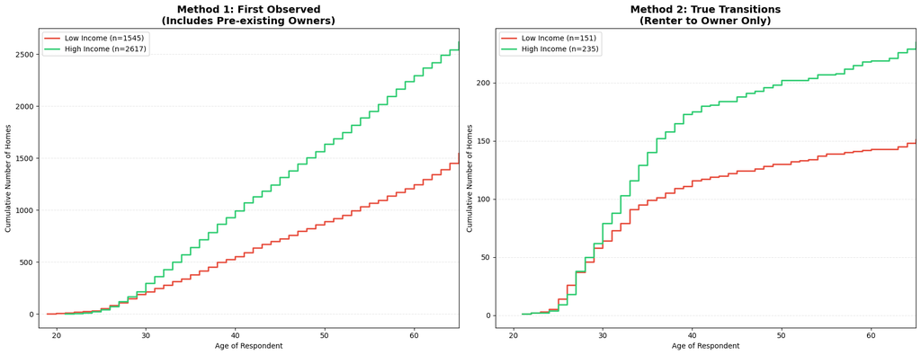

```python
# Median Income Split (based on the full dataset)
median_inc = final_df['gross_hh_income'].median()

# Plotting how homeownership changes over time, both for first-time buyers and first-time havers in the dataset.

fig, (ax1, ax2) = plt.subplots(1, 2, figsize=(18, 7), sharey=False)

#We define a function to plot the datasets
def plot_cumulative_step(data, ax, title, median_val):
    #Split the dataset into income segments
    low_inc = data[data['gross_hh_income'] <= median_val]
    high_inc = data[data['gross_hh_income'] > median_val]

    #Sort and generate counts
    ages_low = np.sort(low_inc['age'].dropna())
    ages_high = np.sort(high_inc['age'].dropna())
    counts_low = np.arange(1, len(ages_low) + 1)
    counts_high = np.arange(1, len(ages_high) + 1)

    # Plot steps
    ax.step(ages_low, counts_low, where='post', label=f'Low Income (n={len(ages_low)})', color='#e74c3c', lw=2)
    ax.step(ages_high, counts_high, where='post', label=f'High Income (n={len(ages_high)})', color='#2ecc71', lw=2)

    # Formatting
    ax.set_title(title, fontsize=14, fontweight='bold')
    ax.set_xlabel('Age of Respondent')
    ax.set_ylabel('Cumulative Number of Homes')
    ax.legend(loc='upper left')
    ax.grid(axis='y', alpha=0.3, linestyle='--')
    ax.set_xlim(18, 65)

# Execute for both sides
plot_cumulative_step(first_home, ax1, 'Method 1: First Observed\n(Includes Pre-existing Owners)', median_inc)
plot_cumulative_step(first_time_buyers, ax2, 'Method 2: True Transitions\n(Renter to Owner Only)', median_inc)

plt.tight_layout()
plt.show()
```

Both plots show an interesting finding - before the age of ~30, the income bracket does not really matter, both groups seem to have a similar (relatively low) number of people able to own a house. However, as respondents get older, the differences start to show and the richer ones are much more likely to be (or become) houseowners. Also, it is clear that, for first-time owners, the biggest difference between the two groups happens in the 30-40 age bracket, and then later the slopes become more similar.

Next, we can measure this statistically, see it as a survival curve. In order to do so properly, we can only use the transition to ownership data, because the larger dataset is left-censored, meaning that their previous data is not known, so it would be wrong to inspect when they became homeowners.

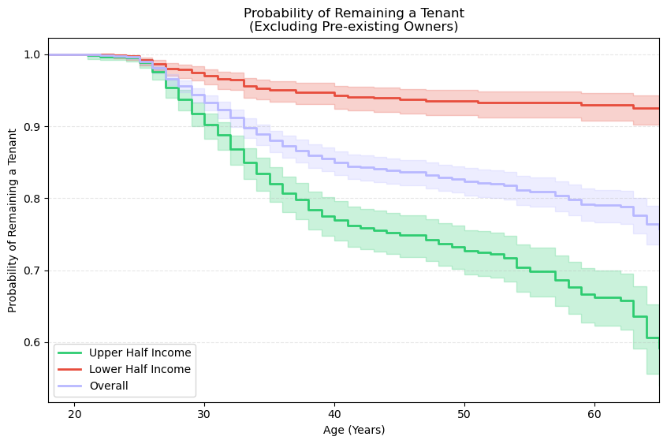

```python
#First, we need to identify and filter out the people who were owners in the same wave they joined the survey.
first_wave_status = final_df.sort_values('survey_date').groupby('person_id').first()
pre_existing_owners = first_wave_status[first_wave_status['is_owner'] == 1].index
survival_base = final_df[~final_df['person_id'].isin(pre_existing_owners)].copy()

#Now, we can define the Event (E) and the Duration (T)
# E: Did they ever become an owner while in the panel?
# T: If yes, age at purchase. If no, age at their last survey.

def get_survival_stats(group):
    # Check if they ever transitioned
    transition = group[(group['is_owner'] == 1)]

    if not transition.empty:
        first_purchase = transition.iloc[0]
        return pd.Series({
            'T': first_purchase['age'],
            'E': 1,
            'gross_hh_income': first_purchase['gross_hh_income'],
            'edu_level': first_purchase['edu_level']
        })
    else:
        last_record = group.iloc[-1]
        return pd.Series({
            'T': last_record['age'],
            'E': 0,
            'gross_hh_income': last_record['gross_hh_income'],
            'edu_level': last_record['edu_level']
        })

# Apply the logic
km_data = survival_base.groupby('person_id').apply(get_survival_stats).reset_index()

# Now we can create a Kaplan-Meier plot to see how many succeeded in buying a home and how many not.
kmf = KaplanMeierFitter()

median_inc = km_data['gross_hh_income'].median()
high_inc_mask = km_data['gross_hh_income'] > median_inc

plt.figure(figsize=(10, 6))

# High Income
kmf.fit(km_data[high_inc_mask]['T'], event_observed=km_data[high_inc_mask]['E'], label='Upper Half Income')
kmf.plot_survival_function(color='#2ecc71', linewidth=2)

# Low Income
kmf.fit(km_data[~high_inc_mask]['T'], event_observed=km_data[~high_inc_mask]['E'], label='Lower Half Income')
kmf.plot_survival_function(color='#e74c3c', linewidth=2)

# Overall

kmf.fit(km_data['T'], event_observed=km_data['E'], label='Overall')
kmf.plot_survival_function(color='#B8B8FF', linewidth=2)


plt.title('Probability of Remaining a Tenant\n(Excluding Pre-existing Owners)')
plt.xlabel('Age (Years)')
plt.ylabel('Probability of Remaining a Tenant')
plt.xlim(18, 65)
plt.grid(axis='y', alpha=0.3, linestyle='--')
plt.show()
```

So, as we can see, more than 75% of participants who were tenants at the start of the survey, remained tenants, even when they were 65. This is especially true for those in the lower half income of the study population, out of which 90% remained tenants.

We can also see whether the difference between low-income and high-income groups is significant, using a log ranks test

```python
results = logrank_test(
    km_data[high_inc_mask]['T'],
    km_data[~high_inc_mask]['T'],
    event_observed_A=km_data[high_inc_mask]['E'],
    event_observed_B=km_data[~high_inc_mask]['E']
)

print(f"P-value: {results.p_value:.4f}")
results.print_summary()
```

```
P-value: 0.0000
```

| t_0 | -1 |
| --- | --- |
| null_distribution | chi squared |
| degrees_of_freedom | 1 |
| test_name | logrank_test |

|  | test_statistic | p | -log2(p) |
| --- | --- | --- | --- |
| 0 | 149.72 | <0.005 | 111.95 |

Of course, it was significant, which would be expected already from the large difference we saw visually. Now that we know how many people are homeowners, let's see **who** they are.

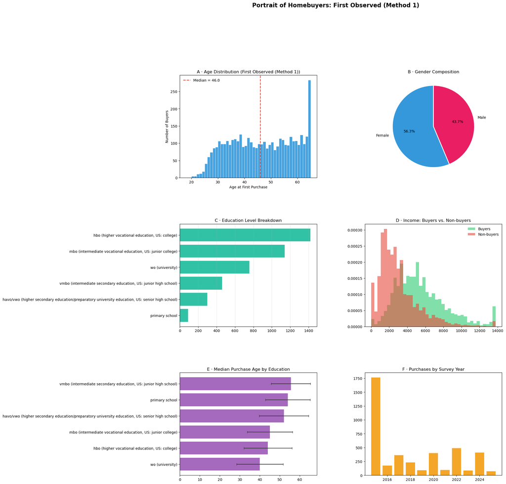

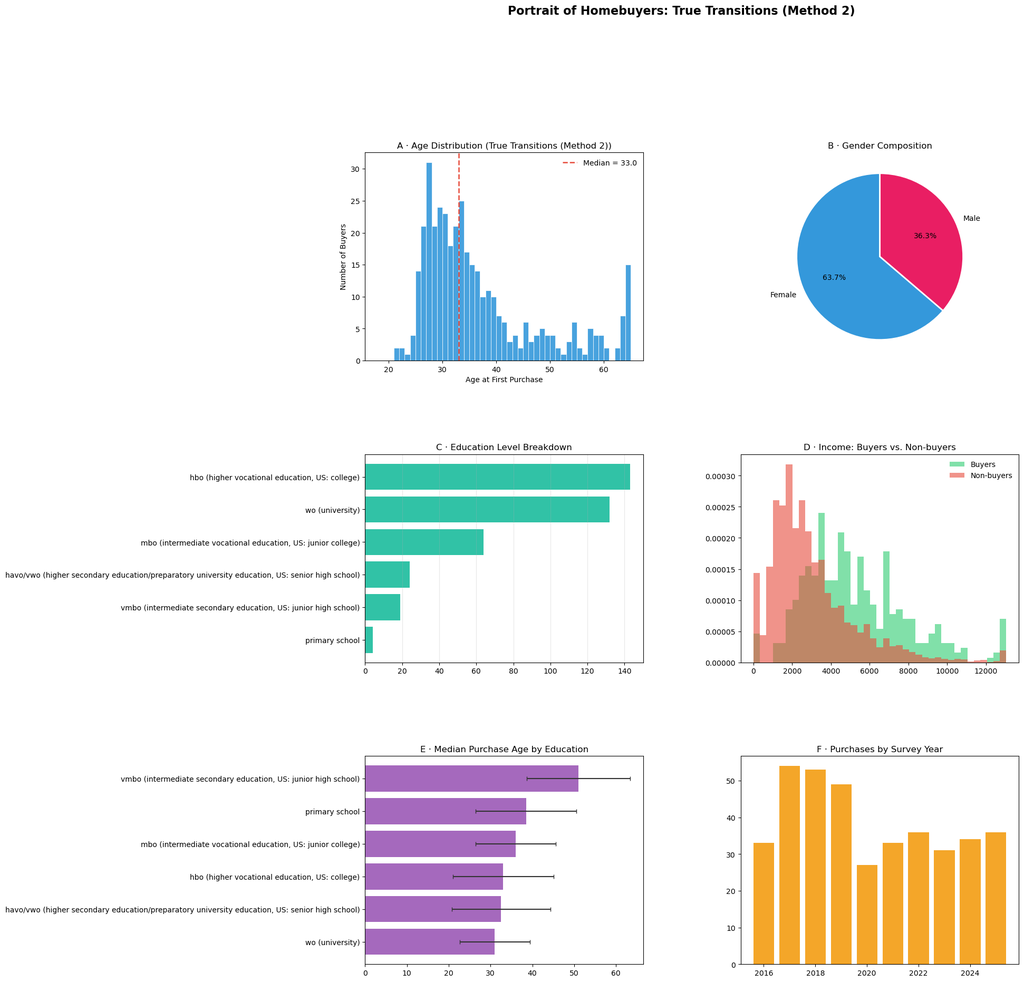

```python
#we can set up a nice color scheme to use for the graphs
PALETTE = {
    'blue': '#3498db', 'pink': '#e91e63', 'teal': '#1abc9c',
    'green': '#2ecc71', 'red': '#e74c3c', 'orange': '#f39c12', 'purple': '#9b59b6'
}

#We can also label the education levels
EDU_MAP = {
    1: 'Primary', 2: 'Lower secondary', 3: 'Upper secondary',
    4: 'Post-secondary\n(non-tertiary)', 5: 'Tertiary\n(bachelor)', 6: 'Tertiary\n(master+)',
}

#Next, we will define a function that will create a nice set of graphs that demonstrate the various aspects of the sample
def generate_demographic_dashboard(df_buyers, df_all_context, title_suffix, filename):
    fh = df_buyers.copy()

    #Preprocessing
    if pd.api.types.is_numeric_dtype(fh['edu_level']):
        fh['edu_label'] = fh['edu_level'].map(EDU_MAP).fillna('Unknown')
    else:
        fh['edu_label'] = fh['edu_level'].astype(str)

    fh['purchase_year'] = fh['survey_date'].dt.year

    #Setting up the plot
    fig = plt.figure(figsize=(16, 20))
    gs  = gridspec.GridSpec(3, 2, figure=fig, hspace=0.45, wspace=0.35)

    # ── A: Age at purchase distribution ──────────────────────────────────────
    ax1 = fig.add_subplot(gs[0, 0])
    ax1.hist(fh['age'].dropna(), bins=range(18, 66), color=PALETTE['blue'],
             edgecolor='white', linewidth=0.6, alpha=0.9)
    median_age = fh['age'].median()
    ax1.axvline(median_age, color=PALETTE['red'], linestyle='--',
                linewidth=1.8, label=f"Median = {median_age:.1f}")
    ax1.set_xlabel('Age at First Purchase')
    ax1.set_ylabel('Number of Buyers')
    ax1.set_title(f'A · Age Distribution ({title_suffix})')
    ax1.legend(frameon=False)

    # ── B: Gender split (pie) ─────────────────────────────────────────────────
    ax2 = fig.add_subplot(gs[0, 1])
    gender_counts = fh['gender'].value_counts()
    ax2.pie(gender_counts.values, labels=gender_counts.index,
            colors=[PALETTE['blue'], PALETTE['pink']], autopct='%1.1f%%', startangle=90,
            wedgeprops={'edgecolor': 'white', 'linewidth': 2})
    ax2.set_title('B · Gender Composition')

    # ── C: Education breakdown (horizontal bar) ───────────────────────────────
    ax3 = fig.add_subplot(gs[1, 0])
    edu_counts = fh['edu_label'].value_counts().sort_values()
    bars = ax3.barh(edu_counts.index, edu_counts.values, color=PALETTE['teal'], alpha=0.9)
    ax3.set_title('C · Education Level Breakdown')
    ax3.grid(axis='x', alpha=0.3)

    # ── D: Income distribution - buyers vs. non-buyers ───────────────────────
    ax4 = fig.add_subplot(gs[1, 1])
    buyers_inc = fh['gross_hh_income'].dropna()
    # Non-buyers are those in the context dataset who are still marked as is_owner == 0
    non_buyers_inc = df_all_context[df_all_context['is_owner'] == 0]['gross_hh_income'].dropna()

    limit = buyers_inc.quantile(0.98)
    bins = np.linspace(0, limit, 40)
    ax4.hist(buyers_inc.clip(upper=limit), bins=bins, alpha=0.6, color=PALETTE['green'], label='Buyers', density=True)
    ax4.hist(non_buyers_inc.clip(upper=limit), bins=bins, alpha=0.6, color=PALETTE['red'], label='Non-buyers', density=True)
    ax4.set_title('D · Income: Buyers vs. Non-buyers')
    ax4.legend(frameon=False)

    # ── E: Median age at purchase by education ────────────────────────────────
    ax5 = fig.add_subplot(gs[2, 0])
    med_age_edu = fh.groupby('edu_label')['age'].agg(['median', 'std']).sort_values('median')
    ax5.barh(med_age_edu.index, med_age_edu['median'], color=PALETTE['purple'], alpha=0.9)
    ax5.errorbar(med_age_edu['median'], med_age_edu.index, xerr=med_age_edu['std'], fmt='none', color='#333', capsize=3)
    ax5.set_title('E · Median Purchase Age by Education')

    # ── F: Purchases by year ──────────────────────────────────────────────────
    ax6 = fig.add_subplot(gs[2, 1])
    year_counts = fh['purchase_year'].value_counts().sort_index()
    ax6.bar(year_counts.index, year_counts.values, color=PALETTE['orange'], alpha=0.9)
    ax6.set_title('F · Purchases by Survey Year')



    fig.suptitle(f'Portrait of Homebuyers: {title_suffix}', fontsize=16, fontweight='bold', y=1.02)
    plt.tight_layout()
    plt.savefig(filename, dpi=150, bbox_inches='tight')
    plt.show()

# ── 2. EXECUTION ─────────────────────────────────────────────────────────────

# Dataset 1: The Original "First Observed" Data
generate_demographic_dashboard(
    first_home,
    final_df,
    "First Observed (Method 1)",
    "portrait_observed.png"
)

# Dataset 2: The Clean "True Transitions" Data
generate_demographic_dashboard(
    first_time_buyers,
    final_df,
    "True Transitions (Method 2)",
    "portrait_transitions.png"
)
```

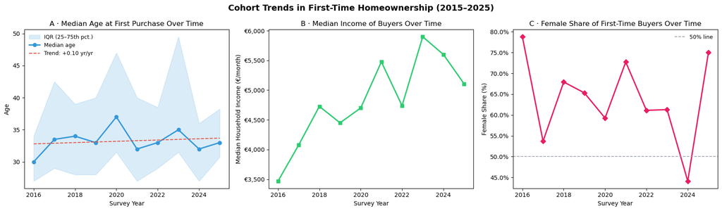

```
 purchase_year  n_buyers  median_age  median_income  pct_female
          2016        33        30.0    3470.000000   78.787879
          2017        54        33.5    4077.134660   53.703704
          2018        53        34.0    4726.804868   67.924528
          2019        49        33.0    4450.000000   65.306122
          2020        27        37.0    4700.000000   59.259259
          2021        33        32.0    5476.000000   72.727273
          2022        36        33.0    4738.181603   61.111111
          2023        31        35.0    5898.000000   61.290323
          2024        34        32.0    5600.000000   44.117647
          2025        36        33.0    5107.000000   75.000000
```

```python
first_time_buyers['purchase_year'] = first_time_buyers['survey_date'].dt.year

cohort = (
    first_time_buyers.groupby('purchase_year')
    .agg(
        n_buyers      = ('person_id', 'count'),
        median_age    = ('age', 'median'),
        q25_age       = ('age', lambda x: x.quantile(0.25)),
        q75_age       = ('age', lambda x: x.quantile(0.75)),
        median_income = ('gross_hh_income', 'median'),
        pct_female    = ('gender', lambda x: (x.str.lower() == 'female').mean() * 100),
    )
    .reset_index()
)

fig, axes = plt.subplots(1, 3, figsize=(17, 5))

# ── A: Median age over time with IQR band ─────────────────────────────────────
ax = axes[0]

ax.fill_between(cohort['purchase_year'], cohort['q25_age'], cohort['q75_age'],
                alpha=0.18, color=PALETTE['blue'], label='IQR (25–75th pct.)')
ax.plot(cohort['purchase_year'], cohort['median_age'], 'o-',
        color=PALETTE['blue'], linewidth=2.2, markersize=6, label='Median age')
ax.set_xlabel('Survey Year')
ax.set_ylabel('Age')
ax.set_title('A · Median Age at First Purchase Over Time')
ax.legend(frameon=False, fontsize=9)
z = np.polyfit(cohort['purchase_year'], cohort['median_age'], 1)
trend_label = f"Trend: {z[0]:+.2f} yr/yr"
ax.plot(cohort['purchase_year'], np.polyval(z, cohort['purchase_year']),
        '--', color=PALETTE['red'], linewidth=1.4, label=trend_label)
ax.legend(frameon=False, fontsize=9)

# ── B: Median household income of buyers over time ───────────────────────────
ax = axes[1]
ax.plot(cohort['purchase_year'], cohort['median_income'], 's-',
        color=PALETTE['green'], linewidth=2.2, markersize=6)
ax.yaxis.set_major_formatter(mtick.FuncFormatter(lambda x, _: f'€{x:,.0f}'))
ax.set_xlabel('Survey Year')
ax.set_ylabel('Median Household Income (€/month)')
ax.set_title('B · Median Income of Buyers Over Time')

# ── C: % female buyers over time ─────────────────────────────────────────────
ax = axes[2]
ax.plot(cohort['purchase_year'], cohort['pct_female'], 'D-',
        color=PALETTE['pink'], linewidth=2.2, markersize=6)
ax.axhline(50, linestyle='--', color='#9CA3AF', linewidth=1.2, label='50% line')
ax.yaxis.set_major_formatter(mtick.PercentFormatter())
ax.set_xlabel('Survey Year')
ax.set_ylabel('Female Share (%)')
ax.set_title('C · Female Share of First-Time Buyers Over Time')
ax.legend(frameon=False, fontsize=9)

fig.suptitle('Cohort Trends in First-Time Homeownership (2015–2025)',
             fontsize=14, fontweight='bold')
plt.tight_layout()
plt.savefig('cohort_trends.png', dpi=150, bbox_inches='tight')
plt.show()

print(cohort[['purchase_year','n_buyers','median_age','median_income','pct_female']].to_string(index=False))
```

Now we can also have a comparison between the buyers and the *non-buyers* over time:

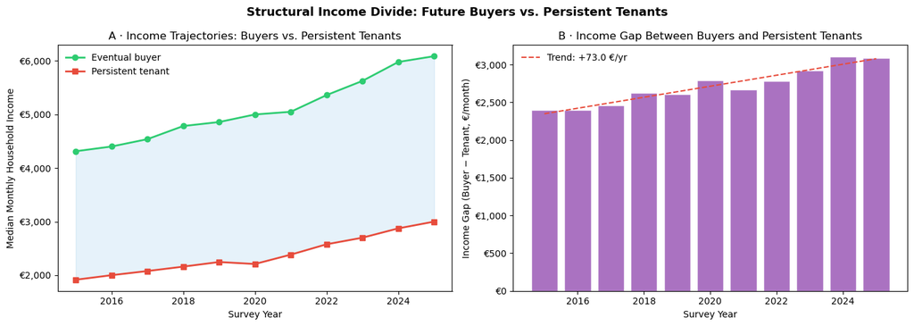

```
Median income by group and year:
ever_buyer  Persistent tenant  Eventual buyer     gap
year
2015                   1915.0          4314.0  2398.0
2016                   2000.0          4402.0  2402.0
2017                   2078.0          4539.0  2461.0
2018                   2160.0          4784.0  2624.0
2019                   2246.0          4859.0  2613.0
2020                   2209.0          5000.0  2791.0
2021                   2384.0          5050.0  2666.0
2022                   2577.0          5362.0  2785.0
2023                   2700.0          5627.0  2927.0
2024                   2874.0          5980.0  3106.0
2025                   3000.0          6088.0  3088.0
```

```python
# Tag each respondent as eventual buyer or persistent tenant
buyers_set = set(first_home['person_id'])
final_df['ever_buyer'] = final_df['person_id'].isin(buyers_set)
final_df['year']       = final_df['survey_date'].dt.year

gap_df = (
    final_df.dropna(subset=['gross_hh_income'])
    .groupby(['year', 'ever_buyer'])['gross_hh_income']
    .median().unstack('ever_buyer')
    .rename(columns={True: 'Eventual buyer', False: 'Persistent tenant'})
    .dropna()
)
gap_df['gap'] = gap_df['Eventual buyer'] - gap_df['Persistent tenant']

fig, (ax1, ax2) = plt.subplots(1, 2, figsize=(14, 5))

# Absolute incomes
ax1.plot(gap_df.index, gap_df['Eventual buyer'],  'o-', color=PALETTE['green'],
         linewidth=2, markersize=6, label='Eventual buyer')
ax1.plot(gap_df.index, gap_df['Persistent tenant'], 's-', color=PALETTE['red'],
         linewidth=2, markersize=6, label='Persistent tenant')
ax1.fill_between(gap_df.index, gap_df['Persistent tenant'], gap_df['Eventual buyer'],
                 alpha=0.12, color=PALETTE['blue'])
ax1.yaxis.set_major_formatter(mtick.FuncFormatter(lambda x, _: f'€{x:,.0f}'))
ax1.set_xlabel('Survey Year')
ax1.set_ylabel('Median Monthly Household Income')
ax1.set_title('A · Income Trajectories: Buyers vs. Persistent Tenants')
ax1.legend(frameon=False)

# Absolute gap
ax2.bar(gap_df.index, gap_df['gap'], color=PALETTE['purple'], edgecolor='white', alpha=0.85)
z = np.polyfit(gap_df.index, gap_df['gap'], 1)
ax2.plot(gap_df.index, np.polyval(z, gap_df.index), '--', color=PALETTE['red'],
         linewidth=1.5, label=f'Trend: {z[0]:+.1f} €/yr')
ax2.yaxis.set_major_formatter(mtick.FuncFormatter(lambda x, _: f'€{x:,.0f}'))
ax2.set_xlabel('Survey Year')
ax2.set_ylabel('Income Gap (Buyer − Tenant, €/month)')
ax2.set_title('B · Income Gap Between Buyers and Persistent Tenants')
ax2.legend(frameon=False)

fig.suptitle('Structural Income Divide: Future Buyers vs. Persistent Tenants',
             fontsize=13, fontweight='bold')
plt.tight_layout()
plt.savefig('income_gap.png', dpi=150, bbox_inches='tight')
plt.show()

print('\nMedian income by group and year:')
print(gap_df.round(0).to_string())
```

As we see, the home buyers have consistently higher incomes, and the difference is getting larger and larger over time, in a linear way.  
Next, we can take another approach and predict current homeownership (at the final study point) based on some characteristics. There are multiple ways to do that. Let's first try a simple logistic regression.

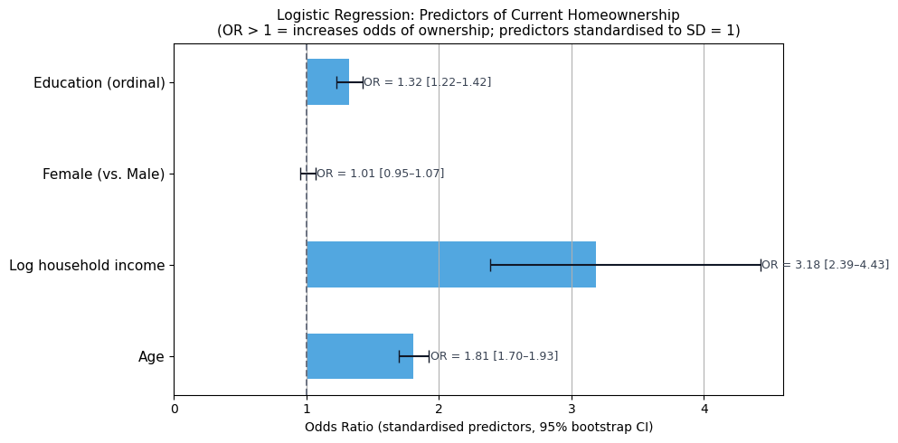

```
--- Logistic Regression Summary ---
  Age                          OR = 1.809  95% CI [1.698, 1.925]
  Log household income         OR = 3.182  95% CI [2.386, 4.425]
  Female (vs. Male)            OR = 1.008  95% CI [0.955, 1.067]
  Education (ordinal)          OR = 1.318  95% CI [1.224, 1.422]
```

```python
# ── Prepare cross-sectional data ──────────────────────────────────────────────
latest = (
    final_df.sort_values('survey_date')
    .groupby('person_id').last().reset_index()
)
latest = latest.dropna(subset=['is_owner', 'gross_hh_income', 'gender', 'edu_level', 'age'])

latest['log_income'] = np.log1p(latest['gross_hh_income'])

# Encode gender
latest['gen_norm'] = latest['gender'].astype(str).str.strip().str.capitalize()
ref_gender = latest['gen_norm'].value_counts().idxmax()  # most common = reference
latest['female'] = (latest['gen_norm'] == 'Female').astype(int)

# Encode education (ordinal - reasonable for LISS edu_level 1–6)
education_mapping = {
    'primary school': 1,
    'vmbo (intermediate secondary education, US: junior high school)': 2,
    'havo/vwo (higher secondary education/preparatory university education, US: senior high school)': 3,
    'mbo (intermediate vocational education, US: junior college)': 4,
    'hbo (higher vocational education, US: college)': 5,
    'wo (university)': 6
}

# Apply the mapping
latest['edu_level_encoded'] = latest['edu_level'].map(education_mapping)

features = ['age', 'log_income', 'female', 'edu_level_encoded']
feature_labels = ['Age', 'Log household income', 'Female (vs. Male)', 'Education (ordinal)']

X = latest[features].values
y = latest['is_owner'].values

scaler = StandardScaler()
X_sc   = scaler.fit_transform(X)

lr = LogisticRegression(max_iter=500)
lr.fit(X_sc, y)

coefs     = lr.coef_[0]
odds_ratios = np.exp(coefs)

# Bootstrap CIs
np.random.seed(42)
n_boot = 500
boot_or = []
for _ in range(n_boot):
    idx = np.random.choice(len(X_sc), len(X_sc), replace=True)
    lr_b = LogisticRegression(max_iter=300)
    lr_b.fit(X_sc[idx], y[idx])
    boot_or.append(np.exp(lr_b.coef_[0]))
boot_or = np.array(boot_or)
ci_lo = np.percentile(boot_or, 2.5, axis=0)
ci_hi = np.percentile(boot_or, 97.5, axis=0)

# Plot Forest Plot
fig, ax = plt.subplots(figsize=(10, 5))

y_pos = np.arange(len(features))
colors_or = [PALETTE['blue'] if o > 1 else PALETTE['red'] for o in odds_ratios]

ax.barh(y_pos, odds_ratios - 1, left=1, color=colors_or, alpha=0.85, height=0.5)
ax.errorbar(odds_ratios, y_pos,
            xerr=[odds_ratios - ci_lo, ci_hi - odds_ratios],
            fmt='none', color='#111827', capsize=5, linewidth=1.5)
ax.axvline(1.0, color='#6B7280', linestyle='--', linewidth=1.4)

for i, (or_, lo, hi) in enumerate(zip(odds_ratios, ci_lo, ci_hi)):
    ax.text(max(or_, hi) + 0.01, i,
            f'OR = {or_:.2f} [{lo:.2f}–{hi:.2f}]',
            va='center', fontsize=9, color='#374151')

ax.set_yticks(y_pos)
ax.set_yticklabels(feature_labels, fontsize=11)
ax.set_xlabel('Odds Ratio (standardised predictors, 95% bootstrap CI)')
ax.set_title('Logistic Regression: Predictors of Current Homeownership\n'
             '(OR > 1 = increases odds of ownership; predictors standardised to SD = 1)',
             fontsize=11)
ax.set_xlim(left=0)
ax.grid(axis='x')
ax.grid(axis='y', alpha=0)

plt.tight_layout()
plt.savefig('logistic_forest.png', dpi=150, bbox_inches='tight')
plt.show()

print('\n--- Logistic Regression Summary ---')
for feat, or_, lo, hi in zip(feature_labels, odds_ratios, ci_lo, ci_hi):
    print(f'  {feat:<28} OR = {or_:.3f}  95% CI [{lo:.3f}, {hi:.3f}]')
```

So, we see household income is the most important feature, followed by age and then by education. Gender actually did not matter at all. This is interesting, given that we have seen that more women *bought* homes during the study period. / In order to see which of these characteristics lead to increased chances to buy a home during the period, let's create a Cox proportional hazards model.

[output not shown]

| null_distribution | chi squared |
| --- | --- |
| degrees_of_freedom | 1 |
| model | <lifelines.CoxPHFitter: fitted with 2513 total... |
| test_name | proportional_hazard_test |

|  |  | test_statistic | p | -log2(p) |
| --- | --- | --- | --- | --- |
| edu_level_encoded | km | 1.81 | 0.18 | 2.48 |
|  | rank | 0.97 | 0.32 | 1.63 |
| female | km | 3.99 | 0.05 | 4.45 |
|  | rank | 5.35 | 0.02 | 5.59 |
| log_income | km | 4.81 | 0.03 | 5.14 |
|  | rank | 4.01 | 0.05 | 4.46 |

[output not shown]

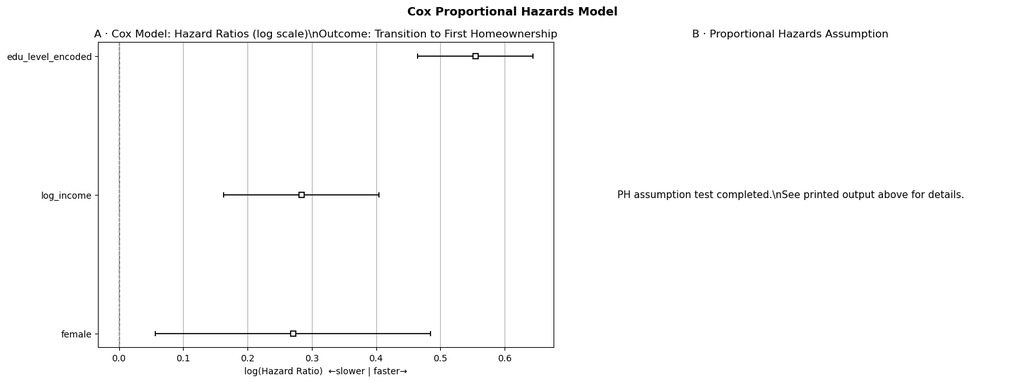

| model | lifelines.CoxPHFitter |
| --- | --- |
| duration col | 'T' |
| event col | 'E' |
| penalizer | 0.01 |
| l1 ratio | 0.0 |
| baseline estimation | breslow |
| number of observations | 2513 |
| number of events observed | 339 |
| partial log-likelihood | -2340.45 |
| time fit was run | 2026-03-25 19:47:24 UTC |

|  | coef | exp(coef) | se(coef) | coef lower 95% | coef upper 95% | exp(coef) lower 95% | exp(coef) upper 95% | cmp to | z | p | -log2(p) |
| --- | --- | --- | --- | --- | --- | --- | --- | --- | --- | --- | --- |
| log_income | 0.28 | 1.33 | 0.06 | 0.16 | 0.40 | 1.18 | 1.50 | 0.00 | 4.61 | <0.005 | 17.93 |
| female | 0.27 | 1.31 | 0.11 | 0.06 | 0.49 | 1.06 | 1.62 | 0.00 | 2.48 | 0.01 | 6.25 |
| edu_level_encoded | 0.55 | 1.74 | 0.05 | 0.46 | 0.64 | 1.59 | 1.90 | 0.00 | 12.16 | <0.005 | 110.60 |

| Concordance | 0.75 |
| --- | --- |
| Partial AIC | 4686.90 |
| log-likelihood ratio test | 237.66 on 3 df |
| -log2(p) of ll-ratio test | 167.81 |

```python
# ── Build Cox dataframe using existing logic ───────────────────────────────────

# Merge 'gender' back into km_data (it was dropped during get_survival_stats)
static_demographics = final_df.groupby('person_id').first()[['gender']].reset_index()
cox_data = pd.merge(km_data, static_demographics, on='person_id', how='left')

# 1. Log transform income
cox_data['log_income'] = np.log1p(cox_data['gross_hh_income'])

# 2. Encode gender (female = 1)
cox_data['female'] = (cox_data['gender'].astype(str).str.strip().str.capitalize() == 'Female').astype(float)

cox_data['edu_level_encoded'] = cox_data['edu_level'].map(education_mapping)

# Subset for the model and drop any rows with missing data
features = ['T', 'E', 'log_income', 'female', 'edu_level_encoded']
cox_df = cox_data[features].dropna()

# Fit the Cox Proportional Hazards Model
cph = CoxPHFitter(penalizer=0.01)
cph.fit(cox_df, duration_col='T', event_col='E')

# ── Plot hazard ratios & assumptions ───────────────────────────────────────────
fig, axes = plt.subplots(1, 2, figsize=(16, 6))

# Plot 1: Hazard Ratios
ax = axes[0]
cph.plot(ax=ax)
ax.axvline(0, color='#9CA3AF', linestyle='--', linewidth=1.2)
ax.set_title('A · Cox Model: Hazard Ratios (log scale)\\n'             'Outcome: Transition to First Homeownership')
ax.set_xlabel('log(Hazard Ratio)  ←slower | faster→')
ax.grid(axis='x')

# Plot 2: Schoenfeld residuals (PH assumption check)
ax = axes[1]
try:
    ph_results = cph.check_assumptions(cox_df, show_plots=False, p_value_threshold=0.05)
    ax.text(0.5, 0.5, 'PH assumption test completed.\\nSee printed output above for details.',
            ha='center', va='center', transform=ax.transAxes, fontsize=11)
except Exception as e:
    ax.text(0.5, 0.5, f'PH check: {e}', ha='center', va='center',
            transform=ax.transAxes, fontsize=9, wrap=True)

ax.set_title('B · Proportional Hazards Assumption')
ax.axis('off')

fig.suptitle('Cox Proportional Hazards Model', fontsize=13, fontweight='bold')
plt.tight_layout()
plt.show()

# Display the summary table
cph.print_summary()
```

```
Proportional hazard assumption looks okay.
```

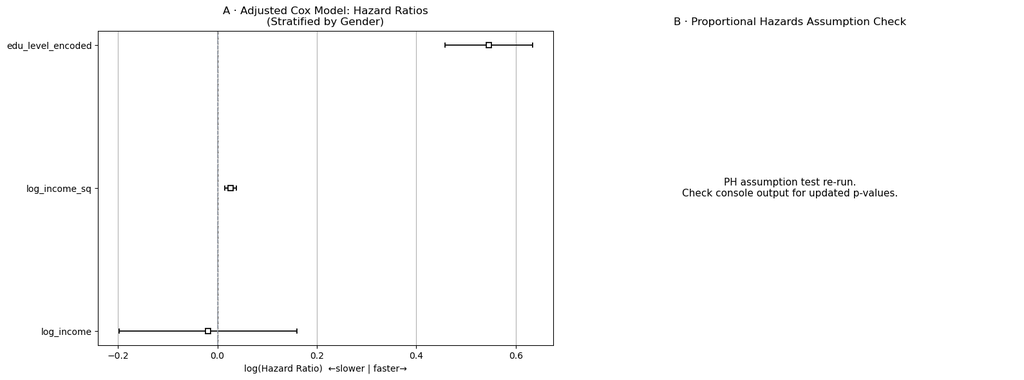

| model | lifelines.CoxPHFitter |
| --- | --- |
| duration col | 'T' |
| event col | 'E' |
| penalizer | 0.01 |
| l1 ratio | 0.0 |
| strata | female |
| baseline estimation | breslow |
| number of observations | 2513 |
| number of events observed | 339 |
| partial log-likelihood | -2112.04 |
| time fit was run | 2026-03-25 19:49:05 UTC |

|  | coef | exp(coef) | se(coef) | coef lower 95% | coef upper 95% | exp(coef) lower 95% | exp(coef) upper 95% | cmp to | z | p | -log2(p) |
| --- | --- | --- | --- | --- | --- | --- | --- | --- | --- | --- | --- |
| log_income | -0.02 | 0.98 | 0.09 | -0.20 | 0.16 | 0.82 | 1.17 | 0.00 | -0.21 | 0.83 | 0.26 |
| log_income_sq | 0.03 | 1.03 | 0.01 | 0.01 | 0.04 | 1.01 | 1.04 | 0.00 | 4.34 | <0.005 | 16.07 |
| edu_level_encoded | 0.55 | 1.73 | 0.04 | 0.46 | 0.63 | 1.58 | 1.88 | 0.00 | 12.21 | <0.005 | 111.48 |

| Concordance | 0.74 |
| --- | --- |
| Partial AIC | 4230.09 |
| log-likelihood ratio test | 249.39 on 3 df |
| -log2(p) of ll-ratio test | 176.24 |

```python
# ── Updated Cox Model addressing PH Assumption Violations ────────────────────

# 1. Ensure we have the base data from km_data and final_df
static_demographics = final_df.groupby('person_id').first()[['gender']].reset_index()
cox_data = pd.merge(km_data, static_demographics, on='person_id', how='left')

# 2. Re-apply transformations
cox_data['log_income'] = np.log1p(cox_data['gross_hh_income'])
cox_data['female'] = (cox_data['gender'].astype(str).str.strip().str.capitalize() == 'Female').astype(int)

cox_data['edu_level_encoded'] = cox_data['edu_level'].map(education_mapping)

# ── ADDRESSING VIOLATIONS ──

# Fix for log_income (Advice 1): Add non-linear term (squared) to improve functional form
cox_data['log_income_sq'] = cox_data['log_income']**2

# Final feature selection (keep 'female' in the dataframe so we can stratify by it)
features = ['T', 'E', 'log_income', 'log_income_sq', 'edu_level_encoded', 'female']
cox_df = cox_data[features].dropna()

# 3. Fit the model with stratification
cph = CoxPHFitter(penalizer=0.01)

# Suppress lifelines-specific warnings (per your previous request)
import warnings
warnings.filterwarnings('ignore', category=UserWarning, module='lifelines')

# Fix for female (Advice): Use 'strata' to allow different baseline hazards by gender
cph.fit(cox_df, duration_col='T', event_col='E', strata=['female'])

# ── Plotting and Summary ──────────────────────────────────────────────────────
fig, axes = plt.subplots(1, 2, figsize=(16, 6))

# Plot 1: Hazard Ratios
ax = axes[0]
cph.plot(ax=ax)
ax.axvline(0, color='#9CA3AF', linestyle='--', linewidth=1.2)
ax.set_title('A · Adjusted Cox Model: Hazard Ratios\n(Stratified by Gender)')
ax.set_xlabel('log(Hazard Ratio)  ←slower | faster→')
ax.grid(axis='x')

# Plot 2: Re-check PH assumption
ax = axes[1]
try:
    # This will check if the new functional form and stratification fixed the issues
    ph_results = cph.check_assumptions(cox_df, show_plots=False, p_value_threshold=0.05)
    ax.text(0.5, 0.5, 'PH assumption test re-run.\nCheck console output for updated p-values.',
            ha='center', va='center', transform=ax.transAxes, fontsize=11)
except Exception as e:
    ax.text(0.5, 0.5, f'PH Check status: {e}', ha='center', va='center',
            transform=ax.transAxes, fontsize=9, wrap=True)

ax.set_title('B · Proportional Hazards Assumption Check')
ax.axis('off')

plt.tight_layout()
plt.show()

# Display results
cph.print_summary()
```

## Summary and Conclusion: First-Time Homeownership Analysis (2015–2025)

This econometric analysis leveraged the **LISS Panel dataset** to provide a longitudinal perspective on the transition to homeownership in the Netherlands. By merging monthly background variables with annual housing modules, we successfully tracked a cohort of individuals over a decade.

This project demonstrates a comprehensive workflow from raw SPSS data extraction to advanced survival modeling, providing actionable insights into the Dutch housing market.

Some additional analyses could have been performed on this dataset. A random forest model could have also been constructed to predict house buying, or a buyer segmentation analyses could have been performed. However, these will be done in other projects within the portfolio.